# ECPA13

Peter Edelsbrunner, Fabian Dablander

2015-07-07

## Vignette Info

This gives an overview of the simulations we presented at [ECPA13](http://www.ecpa13.com/). They demonstrate that itemfit statistics should not be used so recklessly as they currently are in the literature of scientific thinking. The simulated data is included in this package, since running the simulations from scratch takes some time. However, for clarity we have also included the calls made to produce the simulations (in comments).

## Simulation Parameters

```r
source('../R/main.R')
#library('simrasch')

## PARAMETERS
n <- c(100, 300, 1000) # number of participants
items <- c(10, 20, 50) # number of items
corr <- c(.1, .3, .5) # violation of local dependence
discr <- c(.1, .3, .5) # violation of equal item discrimination
```

## Local Dependency

```r
#res_dep1 <- main_sim(n, items, sim.dep, .1)
#res_dep3 <- main_sim(n, items, sim.dep, .3)
#res_dep5 <- main_sim(n, items, sim.dep, .5)
```

## Item Discriminability

```r
#res_2pl1 <- main_sim(n, items, sim.2pl, .1)
#res_2pl3 <- main_sim(n, items, sim.2pl, .3)
#res_2pl5 <- main_sim(n, items, sim.2pl, .5)
```

## Results

```r
load('../data/sim_results.RData')
get_percent <- function(sim) sim$rm_percent
```

Below we look at how the itemfit statistics (infit, standardized p-values) behave under various model misspecifications, and once when the true model is really the Rasch model.

## True model: Rasch

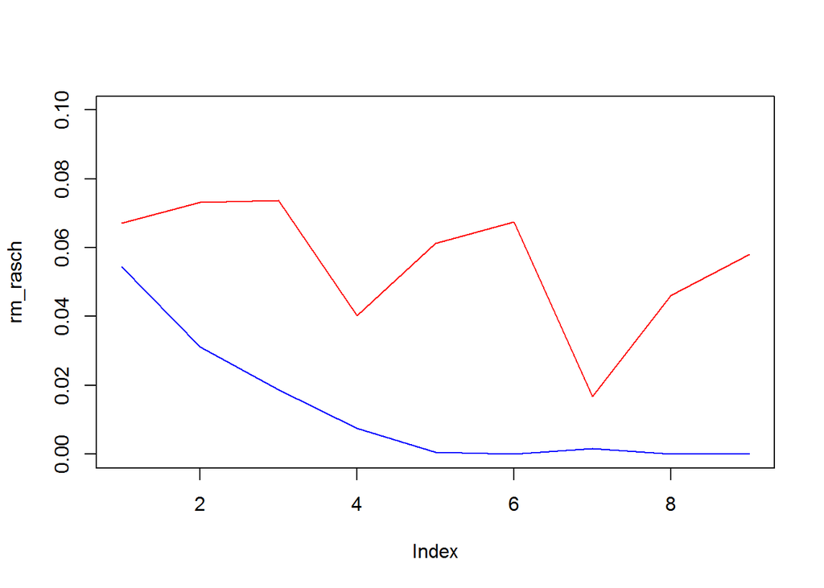

```r
# cutoff c(.8, 1.2) is default
err_rasch <- compute_errors(rasch)
rm_rasch <- sapply(err_rasch, get_percent)
rm_pval <- sapply(err_rasch, function(sim) sim$pval)
plot(rm_rasch, type = 'l', col = 'blue', ylim = c(0, .1))
lines(rm_pval, type = 'l', col = 'red')
```

When the Rasch model is the data generating model, itemfit statistics using the cutoff of .8 and 1.2 are reasonably good they item removal suggestions. With increasing sample size it goes to zero. Standardized p-values, on the other hand, do not show this asymptotically correct behavior; p-values are inconsistent.

## Violation: Item discrimination

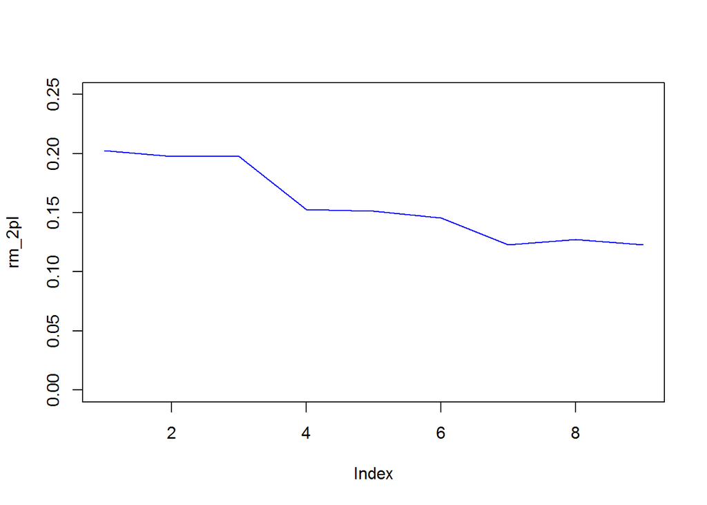

```r
err_2pl <- compute_errors(res_2pl5)
rm_2pl <- sapply(err_2pl, get_percent)
plot(rm_2pl, type = 'l', col = 'blue', ylim = c(0, .25))
```

When the item discrimination is violated, i.e. not equal across items as the Rasch model requires, infit statistics require us to remove approximately 20 percent of the items in small sample size scenarios, and about 12 percent in large sample sizes.

Intriguingly, one can not really conclude anything at this point. One reasoning is that the items are no good, say because of their formulations, and thus need to be removed; or the Rasch model simply is inadequate. The different conclusions nicely embody the difference between the two “Rasch school”, one applied, one theoretical. The fundamental problem is that one cannot make theoretical claims based on such “applied” model fitting procedures.

## Violation: Local Dependence

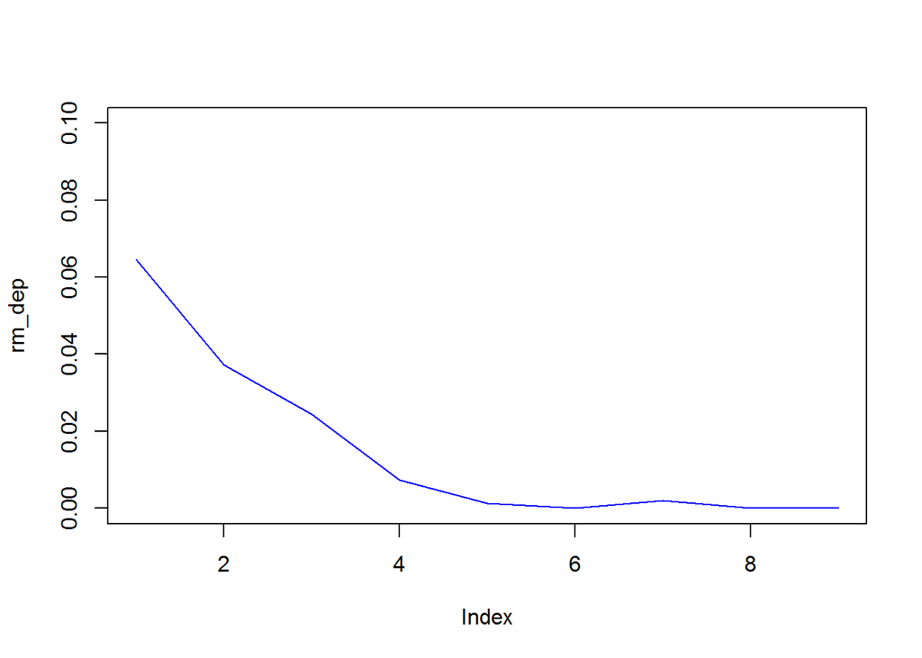

```r
err_dep <- compute_errors(res_dep5)
rm_dep <- sapply(err_dep, get_percent)
plot(rm_dep, type = 'l', col = 'blue', ylim = c(0, .1))
```

When items are pairwisely, but unsystematically correlated (that is, there is no systematic multidimensionality, say if we would have two factors), the infit statistic is absolutely insensitive. Even though the Rasch model is clearly inadequate - local independence is not given! - infit statistics do not capture this.

## Example

Simulate a four-dimensional Model (as common in the literature on scientific reasoning)

```r
library('mirt')
items <- 60
weights <- rbind(c(.5, 0, 0, 0), c(0, .5, 0, 0), c(0, 0, .5, 0), c(0, 0, 0, .5))
wmat <- apply(replicate(items / 4, weights), 2, rbind) # four factors
Sigma <- matrix(c(1, 0.5, 0.4, 0.3, 0.5, 1, 0.6, 0.3, 0.4, 0.6, 1, 0.2, 0.3, 0.3, 0.2, 1), 4)

s <- sim.xdim(1000, 60, Sigma = Sigma, weightmat = wmat)
model <- 'f1=1, 5, 9, 13, 17, 21, 25, 29, 33, 37, 41, 45, 49, 53, 57
          f2=2, 6, 10, 14, 18, 22, 26, 30, 34, 38, 42, 46, 50, 54, 58
          f3=3, 7, 11, 15, 19, 23, 27, 31, 35, 39, 43, 47, 51, 55, 59
          f4=4, 8, 12, 16, 20, 24, 28, 32, 36, 40, 44, 48, 52, 56, 60
          cov=f1*f2*f3*f4'

mrasch <- RM(s)
fitm <- mirt(s, 1, itemtype = 'Rasch')
```

```
##
Iteration: 1, Log-Lik: -36055.089, Max-Change: 0.72285
Iteration: 2, Log-Lik: -35622.995, Max-Change: 0.09000
Iteration: 3, Log-Lik: -35572.609, Max-Change: 0.03178
Iteration: 4, Log-Lik: -35559.865, Max-Change: 0.01531
Iteration: 5, Log-Lik: -35555.666, Max-Change: 0.00848
Iteration: 6, Log-Lik: -35554.093, Max-Change: 0.00507
Iteration: 7, Log-Lik: -35553.454, Max-Change: 0.00318
Iteration: 8, Log-Lik: -35553.188, Max-Change: 0.00202
Iteration: 9, Log-Lik: -35553.074, Max-Change: 0.00132
Iteration: 10, Log-Lik: -35553.023, Max-Change: 0.00226
Iteration: 11, Log-Lik: -35552.998, Max-Change: 0.00119
Iteration: 12, Log-Lik: -35552.987, Max-Change: 0.00122
Iteration: 13, Log-Lik: -35552.982, Max-Change: 0.00031
Iteration: 14, Log-Lik: -35552.980, Max-Change: 0.00020
Iteration: 15, Log-Lik: -35552.979, Max-Change: 0.00012
Iteration: 16, Log-Lik: -35552.978, Max-Change: 0.00011
Iteration: 17, Log-Lik: -35552.978, Max-Change: 0.00006
```

```r
fitpl <- mirt(s, 1, itemtype = '2PL')
```

```
##
Iteration: 1, Log-Lik: -35945.078, Max-Change: 0.50276
Iteration: 2, Log-Lik: -35655.850, Max-Change: 0.17955
Iteration: 3, Log-Lik: -35568.213, Max-Change: 0.10056
Iteration: 4, Log-Lik: -35531.546, Max-Change: 0.05614
Iteration: 5, Log-Lik: -35519.057, Max-Change: 0.03430
Iteration: 6, Log-Lik: -35514.887, Max-Change: 0.01849
Iteration: 7, Log-Lik: -35513.665, Max-Change: 0.01035
Iteration: 8, Log-Lik: -35513.307, Max-Change: 0.00646
Iteration: 9, Log-Lik: -35513.202, Max-Change: 0.00564
Iteration: 10, Log-Lik: -35513.164, Max-Change: 0.00319
Iteration: 11, Log-Lik: -35513.159, Max-Change: 0.00078
Iteration: 12, Log-Lik: -35513.159, Max-Change: 0.00055
Iteration: 13, Log-Lik: -35513.158, Max-Change: 0.00044
Iteration: 14, Log-Lik: -35513.158, Max-Change: 0.00027
Iteration: 15, Log-Lik: -35513.158, Max-Change: 0.00017
Iteration: 16, Log-Lik: -35513.158, Max-Change: 0.00010
```

The reliability of the pseudo one-dimension is:

```r
fscores(fitm, returnER = TRUE)
```

```
##       F1
## 0.585587
```

whereas each subscale (all items that load of exactly one factor) is lower:

```r
f1 <- c(1, 5, 9, 13, 17, 21, 25, 29, 33, 37, 41, 45, 49, 53, 57)
f2 <- c(2, 6, 10, 14, 18, 22, 26, 30, 34, 38, 42, 46, 50, 54, 58)
fit_factor1 <- mirt(s[, f1], 1, temtype = 'Rasch')
```

```
##
Iteration: 1, Log-Lik: -9030.321, Max-Change: 0.33383
Iteration: 2, Log-Lik: -8966.216, Max-Change: 0.14914
Iteration: 3, Log-Lik: -8951.188, Max-Change: 0.07397
Iteration: 4, Log-Lik: -8946.974, Max-Change: 0.03495
Iteration: 5, Log-Lik: -8945.936, Max-Change: 0.02225
Iteration: 6, Log-Lik: -8945.614, Max-Change: 0.01290
Iteration: 7, Log-Lik: -8945.495, Max-Change: 0.00638
Iteration: 8, Log-Lik: -8945.470, Max-Change: 0.00517
Iteration: 9, Log-Lik: -8945.459, Max-Change: 0.00231
Iteration: 10, Log-Lik: -8945.458, Max-Change: 0.00368
Iteration: 11, Log-Lik: -8945.455, Max-Change: 0.00185
Iteration: 12, Log-Lik: -8945.454, Max-Change: 0.00083
Iteration: 13, Log-Lik: -8945.453, Max-Change: 0.00042
Iteration: 14, Log-Lik: -8945.453, Max-Change: 0.00031
Iteration: 15, Log-Lik: -8945.453, Max-Change: 0.00027
Iteration: 16, Log-Lik: -8945.453, Max-Change: 0.00022
Iteration: 17, Log-Lik: -8945.453, Max-Change: 0.00018
Iteration: 18, Log-Lik: -8945.453, Max-Change: 0.00015
Iteration: 19, Log-Lik: -8945.453, Max-Change: 0.00013
Iteration: 20, Log-Lik: -8945.453, Max-Change: 0.00011
Iteration: 21, Log-Lik: -8945.453, Max-Change: 0.00009
```

```r
fit_factor2 <- mirt(s[, f2], 1, temtype = 'Rasch')
```

```
##
Iteration: 1, Log-Lik: -9040.349, Max-Change: 0.34894
Iteration: 2, Log-Lik: -8973.030, Max-Change: 0.15426
Iteration: 3, Log-Lik: -8957.337, Max-Change: 0.07267
Iteration: 4, Log-Lik: -8952.839, Max-Change: 0.04783
Iteration: 5, Log-Lik: -8951.379, Max-Change: 0.02564
Iteration: 6, Log-Lik: -8950.907, Max-Change: 0.01525
Iteration: 7, Log-Lik: -8950.667, Max-Change: 0.00822
Iteration: 8, Log-Lik: -8950.609, Max-Change: 0.00644
Iteration: 9, Log-Lik: -8950.579, Max-Change: 0.00587
Iteration: 10, Log-Lik: -8950.545, Max-Change: 0.00322
Iteration: 11, Log-Lik: -8950.541, Max-Change: 0.00359
Iteration: 12, Log-Lik: -8950.538, Max-Change: 0.00252
Iteration: 13, Log-Lik: -8950.536, Max-Change: 0.00081
Iteration: 14, Log-Lik: -8950.536, Max-Change: 0.00068
Iteration: 15, Log-Lik: -8950.535, Max-Change: 0.00052
Iteration: 16, Log-Lik: -8950.535, Max-Change: 0.00027
Iteration: 17, Log-Lik: -8950.535, Max-Change: 0.00019
Iteration: 18, Log-Lik: -8950.535, Max-Change: 0.00015
Iteration: 19, Log-Lik: -8950.535, Max-Change: 0.00012
Iteration: 20, Log-Lik: -8950.535, Max-Change: 0.00009
```

```r
fscores(fit_factor1, returnER = TRUE)
```

```
##        F1
## 0.4185086
```

```r
fscores(fit_factor2, returnER = TRUE)
```

```
##        F1
## 0.4114243
```

But these factors measure something distinct! By aggregating over the factors we actually loose information.

## itemfits in four-dimensional space

We see that itemfit statistics **completely miss the point**.

```r
pp <- person.parameter(mrasch)
eRm::itemfit(pp)
```

```
##
## Itemfit Statistics:
##        Chisq  df p-value Outfit MSQ Infit MSQ Outfit t Infit t
## I1   964.543 999   0.778      0.965     0.973    -0.93   -0.83
## I2   974.466 999   0.705      0.974     0.976    -1.32   -1.41
## I3  1005.572 999   0.436      1.006     1.007     0.35    0.48
## I4  1006.529 999   0.427      1.007     1.008     0.34    0.49
## I5  1001.287 999   0.474      1.001     1.001     0.09    0.11
## I6   988.473 999   0.588      0.988     0.997    -0.19   -0.06
## I7  1002.519 999   0.463      1.003     1.002     0.16    0.16
## I8  1017.269 999   0.337      1.017     0.996     0.28   -0.05
## I9   995.637 999   0.524      0.996     0.995    -0.17   -0.22
## I10 1012.953 999   0.372      1.013     1.013     0.65    0.74
## I11  971.897 999   0.725      0.972     0.974    -0.72   -0.79
## I12 1006.164 999   0.431      1.006     1.009     0.29    0.45
## I13  993.909 999   0.539      0.994     0.983    -0.13   -0.46
## I14  986.883 999   0.602      0.987     0.989    -0.15   -0.15
## I15 1003.939 999   0.450      1.004     1.005     0.18    0.26
## I16  963.402 999   0.786      0.963     0.980    -0.46   -0.28
## I17 1017.832 999   0.332      1.018     1.014     0.81    0.72
## I18  998.572 999   0.498      0.999     0.989    -0.03   -0.33
## I19  988.399 999   0.588      0.988     0.992    -0.43   -0.36
## I20  999.607 999   0.489      1.000     0.995     0.00   -0.18
## I21 1018.136 999   0.330      1.018     1.016     0.88    0.92
## I22  980.317 999   0.658      0.980     0.986    -0.47   -0.39
## I23 1008.555 999   0.410      1.009     1.006     0.55    0.44
## I24  994.141 999   0.537      0.994     0.998    -0.13   -0.05
## I25  993.368 999   0.544      0.993     0.977    -0.02   -0.20
## I26 1002.609 999   0.462      1.003     0.998     0.18   -0.16
## I27  995.107 999   0.529      0.995     0.995    -0.23   -0.26
## I28  987.832 999   0.593      0.988     0.992    -0.60   -0.46
## I29  976.488 999   0.689      0.976     0.983    -1.17   -0.97
## I30  989.328 999   0.580      0.989     0.994    -0.67   -0.45
## I31  958.857 999   0.815      0.959     0.977    -0.54   -0.34
## I32 1012.010 999   0.380      1.012     1.005     0.30    0.14
## I33  978.644 999   0.671      0.979     0.982    -1.39   -1.31
## I34  979.875 999   0.661      0.980     0.984    -1.35   -1.21
## I35  921.001 999   0.962      0.921     0.956    -1.04   -0.64
## I36 1031.537 999   0.231      1.032     1.028     1.23    1.26
## I37  978.059 999   0.676      0.978     0.983    -0.64   -0.59
```

[output cut: 8 more lines]

```
## I46  983.382 999   0.632      0.983     0.991    -0.59   -0.35
## I47 1034.439 999   0.212      1.034     1.001     0.57    0.04
## I48 1014.261 999   0.361      1.014     1.004     0.51    0.16
## I49  985.643 999   0.612      0.986     0.985    -0.38   -0.47
## I50  994.055 999   0.538      0.994     0.995    -0.37   -0.33
## I51  977.746 999   0.679      0.978     0.990    -0.65   -0.35
## I52 1039.176 999   0.184      1.039     1.006     0.72    0.14
## I53  981.843 999   0.645      0.982     0.985    -0.43   -0.41
## I54  947.979 999   0.874      0.948     0.968    -1.27   -0.89
## I55  988.348 999   0.589      0.988     0.988    -0.28   -0.34
## I56  981.712 999   0.646      0.982     0.988    -0.51   -0.39
## I57 1008.134 999   0.413      1.008     1.007     0.28    0.30
## I58  956.239 999   0.830      0.956     0.964    -1.36   -1.32
## I59  978.201 999   0.675      0.978     0.980    -1.48   -1.50
## I60  999.223 999   0.492      0.999     1.002    -0.05    0.13
```

```r
start <- Sys.time()
#res <- NPtest(s, n = 50, method = 'MLoef', splitcr = rep(1:4, times = 15))
end <- Sys.time()
```